# Computer Science 1

**Computer lab 02**

**Course Number:** BTPS1210BA-E  
**Contact Information:** Please contact me through email anytime: abari.kalman@arts.unideb.hu

Author

Kálmán Abari

Published

August 28, 2024

Learning outcomes

Students will learn how to use RStudio and how to create and render Quarto documents.

# RStudio reporting

## Problem 1

> In this section, you will learn how to create, edit and render Quarto document.
1. Create a new Quarto document `why_do_we_learn_statistics.qmd` in RStudio. In the dialoge box that appears, type `Why do we learn statistics?` into the field **Title**, and your own name into in the field **Author**. Uncheck the `Use visual markdown editor` box. Click on `Create` button.
2. Delete all content under the header. The header looks something like this:

```yaml
---
title: "Why do we learn statistics?"
author: "Kálmán Abari"
format: html
---
```

3. Modify the header. Change the line`format: html` to this text:

```yaml
format:
  html:
    embed-resources: true
    self-contained-math: true
```

The new header looks like this:

```yaml
---
title: "Why do we learn statistics?"
author: "Kálmán Abari"
format:
  html:
    embed-resources: true
    self-contained-math: true
---
```

4. After skipping an empty line, type the following text under the header (please, do not use `Ctrl+C/Ctrl+V`):

```markdown
# On the psychology of statistics

Not surprisingly, there’s a pretty large proportion of the student base that isn’t happy about the fact that psychology has so much statistics in it. Why does psychology have so much statistics?

- Psychology is an empirical science. Psychologists test their theories by comparing the predictions from theories to **actual data**.
- We live in the 21st century, and data are *everywhere*. Statistics is one of the most important things that you can study.
```

5. Save the file `why_do_we_learn_statistics.qmd`. It looks something like this:

```yaml
---
title: "Why do we learn statistics?"
author: "Kálmán Abari"
format:
  html:
    embed-resources: true
    self-contained-math: true
---

# On the psychology of statistics

Not surprisingly, there’s a pretty large proportion of the student base that isn’t happy about the fact that psychology has so much statistics in it. Why does psychology have so much statistics?

- Psychology is an empirical science. Psychologists test their theories by comparing the predictions from theories to **actual data**.
- We live in the 21st century, and data are *everywhere*. Statistics is one of the most important things that you can study.
```

5. Render (generate) HTML file from `why_do_we_learn_statistics.qmd`. Click on `Render` button. Find the HTML file in your *File Explorer*, and open it in Chrome. The file `why_do_we_learn_statistics.html` looks something like this:

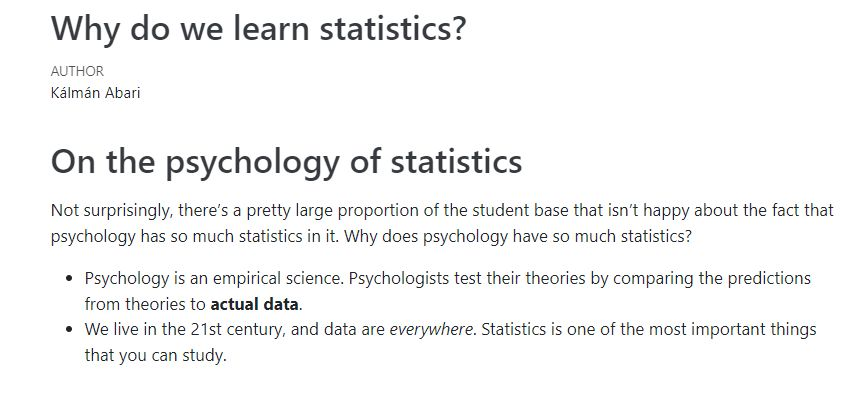

HTML file ‘Why do we learn statistics?’

6. Send the file `why_do_we_learn_statistics.html` to the `abari.kalman@arts.unideb.hu`. The subject of this email is `Problem 1`.

## Problem 2

> In this section, you will learn how to use markdown language in Quarto document.
1. Create a new Quarto document `scales_of_measurement.qmd` in RStudio. In the dialog box that appears, type `Scales of measurement` into the field **Title**, and your own name into in the field **Author**. Uncheck the `Use visual markdown editor` box. Click on `Create` button.
2. Delete all content under the header. The header looks something like this:

```yaml
---
title: "Scales of measurement"
author: "Kálmán Abari"
format: html
---
```

3. Modify the header. Change the line`format: html` to this text:

```yaml
format:
  html:
    embed-resources: true
    self-contained-math: true
```

The new header looks like this:

```yaml
---
title: "Scales of measurement"
author: "Kálmán Abari"
format:
  html:
    embed-resources: true
    self-contained-math: true
---
```

4. After skipping an empty line, type the following text under the header (you can use `Ctrl+C/Ctrl+V`):

```markdown
# A brief introduction to research design

> *"To consult the statistician after an experiment is finished is often merely to ask him to conduct a post mortem examination. He can perhaps say what the experiment died of."*\
> -- Sir Ronald Fisher

## Scales of measurement

### Nominal scale

A **nominal scale** variable (also referred to as a **categorical** variable) is one in which there is no particular relationship between the different possibilities.

More information is [here](https://davidfoxcroft.github.io/lsj-book/02-A-brief-introduction-to-research-design.html).

| Transportation | Number of people |
|----------------|------------------|
| Train          | 12               |
| Bus            | 30               |
| Car            | 48               |
| Bicycle        | 10               |

: How did 100 people get to work today
```

5. Render (generate) HTML file from `scales_of_measurement.qmd`. Click on `Render` button. Find the HTML file in your *File Explorer*, and open it in Chrome. The file `scales_of_measurement.html` looks something like this:

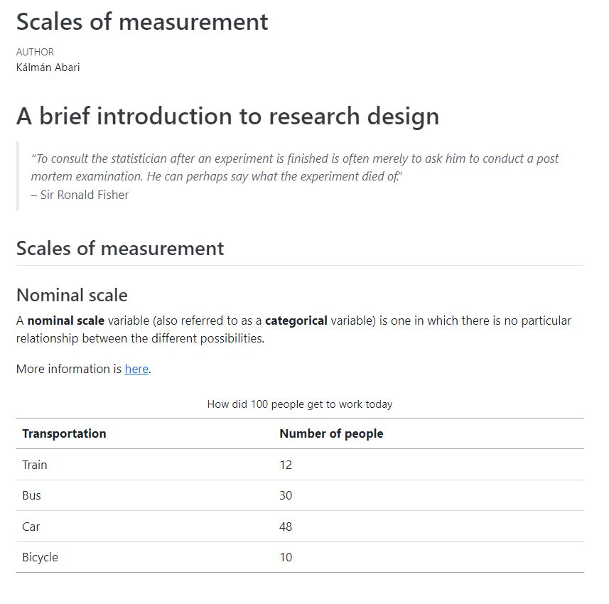

HTML file ‘Scales of measurement’

## Problem 3

> In this section, you will learn how to handle RStudio projects and markdown images and code blocks.
1. Create a new RStudio project. Select `File / New project` menu, then `New directory` and `New Project` buttons. Browse your `BASEDIR` into field `Create project as subdirectory of`. Name your project as `first_project` in field `Directory name`. Click on `Create` button.
2. Create a new directory `images` in `first_project` folder.
3. Download [this image (size 1280x853)](https://pixabay.com/photos/psychology-psyche-mask-wire-frame-2706902/) and copy to `images` folder. Rename file `psychology-2706902_1280.jpg` to `psychology.jpg`.
4. Create a new Quarto document `markdown_images.qmd` in RStudio. In the dialog box that appears, type `Images in Quarto documents` into the field **Title**, and your own name into in the field **Author**. Uncheck the `Use visual markdown editor` box. Click on `Create` button.
5. Delete all content under the header. The header looks something like this:

```yaml
---
title: "Images in Quarto documents"
author: "Kálmán Abari"
format: html
---
```

3. Modify the header. Change the line`format: html` to this text:

```yaml
format:
  html:
    embed-resources: true
    self-contained-math: true
toc: true
toc-location: left
```

The new header looks like this:

```yaml
---
title: "Images in Quarto documents"
author: "Kálmán Abari"
format:
  html:
    embed-resources: true
    self-contained-math: true
toc: true
toc-location: left
---
```

4. After skipping an empty line, type the following text under the header (you can use `Ctrl+C/Ctrl+V`):

````markdown
# Figures

Quarto includes a number of features aimed at making it easier to work with figures and subfigures, as well as for laying out panels that contain multiple figures, tables, or other content.

## Figure Basics

In markdown, a figure is created whenever a captioned image appears by-itself in a paragraph. For example:

```md
![Psychology](images/psychology.jpg)
```

![Psychology](images/psychology.jpg)


### Source Code

As you see above, we can use `` ``` `` to delimit blocks of source code. To markdown text use as open part `` ```md ``. You can find more details [here](https://quarto.org/docs/authoring/markdown-basics.html#source-code).


## Figure Sizing

By default figures are displayed using their actual size (subject to the width constraints imposed by the page they are rendered within). You can change the display size by adding the width and height attributes to the figure. For example:

```md
![Psychology](images/psychology.jpg){width=200}
```

![Psychology](images/psychology.jpg){width=200}

Note that if only width is specified then height is calculated automatically. If you need to modify the default behaviour just add an explicit height attribute.

The default units for width and height are pixels. You can also specify sizes using a percentage or a conventional measurement like inches or millimetres. For example:

```md
![Psychology](images/psychology.jpg){width=80%}
```

![Psychology](images/psychology.jpg){width=80%}


```md
![Psychology](images/psychology.jpg){width=4in}
```

![Psychology](images/psychology.jpg){width=4in}


## Linked Figures

When rendering with Quarto, you can enclose a figure within a link and it will still be treated within output as a captioned figure. For example:

```md
[![Psychology](images/psychology.jpg){width=50%}](https://en.wikipedia.org/wiki/Psychology)
```

[![Psychology](images/psychology.jpg){width=50%}](https://en.wikipedia.org/wiki/Psychology)

## Figure Alignment

Figures are center aligned by default. Add the fig-align attribute to the image to use a different alignment. For example:

```md
![Psychology](images/psychology.jpg){fig-align="left" width=25%}
```

![Psychology](images/psychology.jpg){fig-align="left" width=25%}

Note that figure captions are left aligned to accommodate longer caption text (which looks odd when center aligned).

## Alt Text

You can add alternative text to a figure by adding the fig-alt attribute to the image. ([Why is alt text important?](https://moz.com/learn/seo/alt-text)) For example, the following Markdown…

```md
![](images/psychology.jpg){fig-alt="Psychology mask image from Pixabay.com."}
```

![](images/psychology.jpg){fig-alt="Psychology mask image from Pixabay.com."}


Note that the figure caption, title, and alt text can all be different. For example, the following code…

```md
![Psychology (caption)](images/psychology.jpg "Psychology (title)"){fig-alt="Psychology mask image from Pixabay.com."}
```

![Psychology (caption)](images/psychology.jpg ){fig-alt="Psychology mask image from Pixabay.com."}

## Applying Multiple Parameters

To combine the above methods, separate arguments by a space, for example:

```md
![Psychology (caption)](images/psychology.jpg "Psychology (title)"){fig-alt="Psychology mask image from Pixabay.com." fig-align="left" width=20%}
```

![Psychology (caption)](images/psychology.jpg "Psychology (title)"){fig-alt="Psychology mask image from Pixabay.com." fig-align="left" width=20%}
````

5. Render (generate) HTML file from `markdown_images.qmd`. Click on `Render` button. Find the HTML file in your *File Explorer*, and open it in Chrome. The file `markdown_images.html` looks something like this:

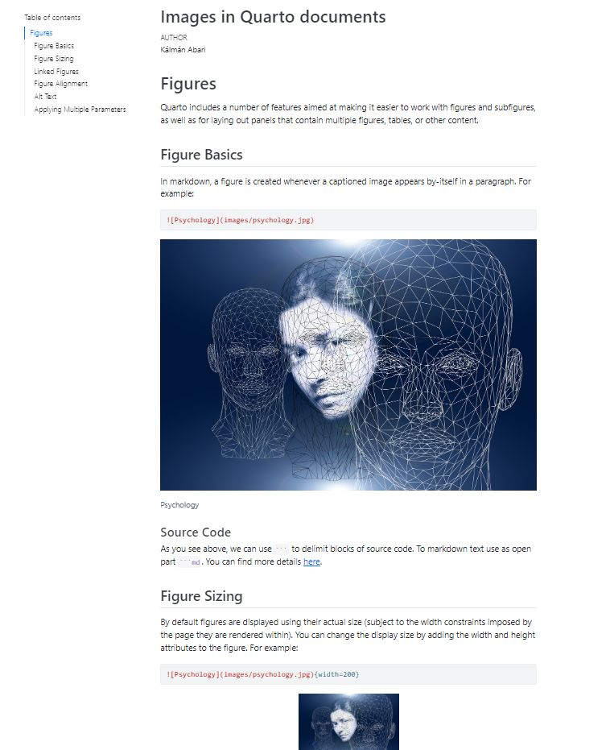

6. Send the file `markdown_images.html` to the `abari.kalman@arts.unideb.hu`. The subject of this email is `Problem 3`.

## Problem 4

> In this section, you will learn how to note in RStudio.
1. Download and open `note_in_rstudio.html` from [here](https://github.com/abarik/computer_science_1_2023_24_1/blob/f8bb56152f756701d29d74d52bbbb376f3abfd2c/files/note_in_rstudio.html).
2. Create a new RStudio project (`note_in_rstudio`) and a new Quarto document (`note_in_rstudio.qmd`). Modify the `note_in_rstudio.qmd` file based on `note_in_rstudio.html`. **The more similar HTML files you create, the more badges you get (from three to zero).**
3. Send your `note_in_rstudio.html` to the `abari.kalman@arts.unideb.hu`. The subject of this email is `Problem 4`.